# 환경 빅데이터 뉴스레터: 2023년 8월

sung won kang

2023 9 8

## Summary

> 2023년 8월에 게시된 네이버 환경뉴스를 분석한 결과 후쿠시마 원전 오염수 방류, 기후변화, 탄소중립 관련 키워드가 빈번하게 출현하였다.환경무 문헌의 키워드에서는 기후변화, 탄소중립 관련 키워드가 빈번하게 출현하여 후쿠시마 원전 오염수 방류를 제외한 이슈에 대해서는 네이버 환경뉴스 키워드와 조응하는 경향이 있었다. 환경부 문헌에서는 환경규제 개선 및 민관 업무협약 관련 키워드가 빈번하게 출현하였으나, 네이버 환경뉴스에서는 이와 관련된 키워드가 빈번하게 출현하지 않았다.

텍스트 분석 바로가기

> 2023년 7월 1주차에는 chlorophyll-a 예측치가 25$\mu g/m^3$ 이상이어서 녹조 농도가 높을 것으로 예측되는 측정소는 ‘곡교천2, 논산천4,금호강8,구포,학성,남강7,남지’ 측정소이다.

녹조 예측 바로가기

대기오염,기후변화,탄소중립 질문기반DB 바로가기

## 1. 텍스트분석

- 한국환경연구원 텍스트 수집 도구는 2023년 8월 31일까지 네이버 기사 데이터와 환경부 문헌 데이터를 제공한다. 아래 뉴스레터에서는 2023년 8월 2일을 기점으로 31일 이전까지 수집한 자료를 사용한다.

#### A. Text 데이터

분석 대상 Text Data는 다음 두 종류의 문헌을 자료이다.

1. NAVER 환경 뉴스 : 2023년 8월 2일-2023년 8월 31일 NAVER 뉴스> ‘사회’ >‘환경’ 부문에 게시된 뉴스
2. 환경부 문건 : 2023년 8월 2일-2023년 8월 31일 환경부홈페이지에 게시된 환경부 보도자료 및 e-환경뉴스

’NAVER 환경 뉴스’는 환경정책의 수요자인 국민의 환경과 관련된 관심사를 전달하는 텍스트 자료이다. 그리고 ’환경부 문건’은 환경정책의 공급자인 환경부의 관심사를 전달하는 텍스트 자료이다. 이 두 자료의 키워드를 비교하여 환경정책 공급자의 관심사가 환경정책 수요자의 관심사에 조응하는지 여부를 점검한다.

#### B. 키워드 빈도분석

한국환경연구원의 환경 빅데이터 플랫폼에서는 키워드를 단순빈도수 및 TF_IDF 값에 따라 추출한다. 키워드 추출 전단계로 파이선’konlpy’패키지를 활용한 형태소 분석 및 품사 태깅을 수행하고, 불용어(stopwords)를 제거한다. 2023년 8월 2일 - 8월 31일 게시 NAVER 환경뉴스 및 환경부 문건에서 단순빈도수가 높은 20개의 키워드를 추출한 결과는 아래 그림과 같다.

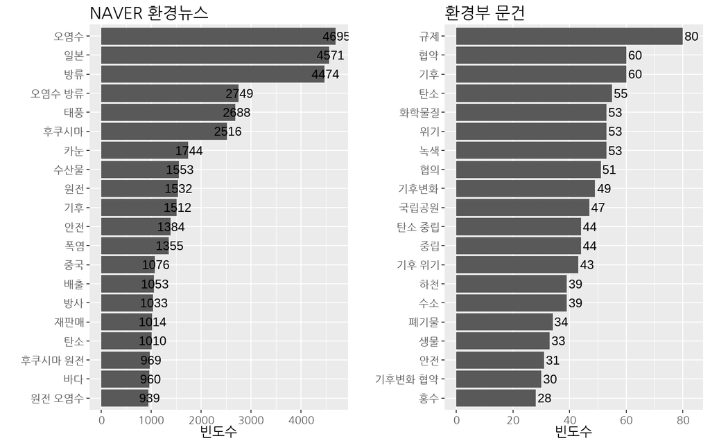

눈에 띄는 특징은 다음과 같이 정리할 수 있다.

- 첫째, 네이버 환경뉴스에는 빈도수가 높은 상위 20개 키워드 중 ‘태풍’,‘카눈’,‘폭염’과 같이 하절기 극단적 기후현상과 관련된 키워드가 다수 발견되었다. 환경부 문건의 빈도수 상위 20개 키워드 중에도 ’홍수’ 와 같이 이에 상응하는 키워드가 발견되었다. 그리고 네이버 뉴스의 ‘일본’ 키워드는 일본이 태풍 카논의 경로에 포함되었기 때문에 ’태풍’과 관련된 관심과도 관련이 있었다.
- 둘째, 네이버 환경뉴스에는 빈도수가 높은 상위 20개 키워드 중 ‘오염수’,‘일본’,‘중국’,‘방류’,‘후쿠시마’,‘수산물’,‘방사’ 가 발견되어 후쿠히마 원전 가동과 관련된 관심이 유지되었음을 시사하였으나, 환경부 문헌에서는 이에 상응하는 키워드는 발견되지 않았다.
- 셋째, 네이버 환경뉴스에는 빈도수가 높은 상위 20개 키워드 중 ‘탄소’,‘기후’와 같이 기후변화 관련 키워드가 발견되었으며 환경부 보도자료에도 이에 상응하는 ’탄소’,‘탄소 중립’,‘중립’,‘기후’,‘위기’,’기후위기’와 같은 키워드가 발견되었다.
- 넷째, 환경부 문건의 빈도수 상위 20개 키워드 중에는 ‘규제’,‘화학물질’,‘녹색’,‘하천’,‘수소’,‘폐기물,’ 생물’ 등 다양한 환경정책 관련 키워드와 ‘협의’,‘협약’,’기후변화 협약’과 같이 환경정책 추진을 위한 민-관 협력 및 국가간 협력에 대한 키워드가 발견되지만, 네이버 환경뉴스에서는 이에 상응하는 키워드가 발견되지 않았다.

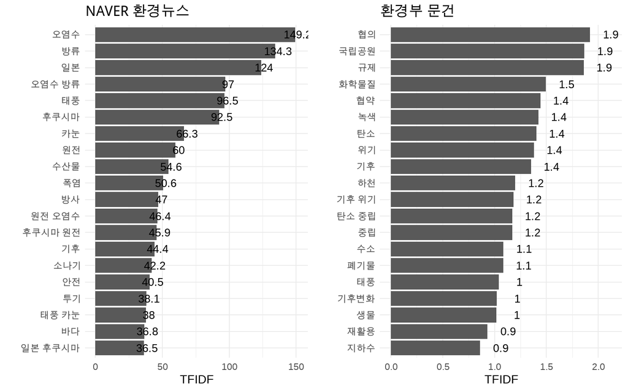

#### C. 키워드 관련 뉴스

네이버 환경뉴스 키워드와 환경부 문건 키워드간의 차이의 원인을 파악하기 위해서 두 문헌에서 단순빈도가 가장 높은 10개 키워드 중 서로 상이한 키워드가 포함된 문헌의 제목들을 비교하였다.

- 네이버 환경뉴스에서 단순빈도가 높은 10개 키워드 중 환경부 문건의 단순빈도가 높은 20개 키워드에 포함되지 않은 키워드는 [오염수, 일본, 방류, 오염수 방류, 태풍, 후쿠시마, 카눈, 수산물, 원전]이다. 이들 중 ‘태풍’,’카눈’은 태풍에 관련된 키워드로서 환경부 문헌의 키워드 ’홍수’와 연관이 있다.
- 환경부 문헌에서 단순빈도가 높은 10개 키워드 중 네이버 환경뉴스에서 단순빈도가 높은 20개 키워드에 포함되지 않은 키워드는 [규제, 협약, 위기, 녹색, 화학물질, 협의, 기후변화, 국립공원]이다.
1. ‘오염수’, ‘일본’,‘후쿠시마’,‘수산물’,‘원전’을 제목에 포함하는 기사들은 후쿠시마 제1원자력발전소 오염수 방류와 관련된 기사로 파악되었다. 반면 ’방류’를 제목에 포함하는 기사들 중에서는 인천시의 참조기 치어 방류와 관련된 기사도 있었다. 아래의 표에서 ’태풍’ 혹은 ’카논’을 제목에 포함한 기사는 제외되었다.

| Title |
| --- |
| “日 오염수 투기 저지” 광주 주민단체 삭발·단식 |
| 日어민, 원전 장관에 “방류 전인데 수출 안돼…소문피해 대책을” |
| 인천시, 연평도 해역에 참조기 치어 25만마리 방류 |
| 인천시 수산자원연구소, 연평도해역에 어린 참조기 25만마리 방류 |
| “후쿠시마 오염수 우리 해역 영향 미미…해산물 안전” |
| 정부 “오염수 한일 추가 실무협의, 오는 7일 화상으로 개최” |
| 후쿠시마 오염수 해양투기에 국민 소송으로 맞서다 |
| 정부 “오염수 한일 추가 실무협의, 오는 7일 화상으로 개최”(종합) |
| 피지 총리 ‘IAEA 오염수 보고서’ 긍정 평가…日 “깊이 감사” |
| 한일, 이번주 오염수 실무협의… 한미일 정상회담 앞두고 성과 낼까 |
| 수협-KMI, 8일 부산서 ‘원전 오염수 논란 영향과 대응방안’ 토론회 개최 |
| 후쿠시마 원전 오염수 관련 정부 입장 설명하는 박구연 국무조정실 1차장 |
| 환경운동연합, ‘후쿠시마 오염수 해양투기 반대’ 기자회견 |
| 수산물 방사능 관리 현황 설명하는 박성훈 차관 |
| 세종문화회관 앞 후쿠시마 오염수 해양투기 반대 퍼포먼스 |

환경부 문헌에서 가장 빈도가 높은 10개 키워드 중 네이버 뉴스에서 가장 빈도가 높은 키워드 20개에 포함되지 않은 키워드는 ‘규제’,‘협약’,‘위기’,‘녹색’,‘화학물질’,‘협의’,‘기후변화’,‘국립공원’ 이다. 이 중 ’기후변화’는 네이버 뉴스의 키워드 중 ’기후’에 조응한다. 그 외의 키워드에 조응하는 네이버 뉴스 키워드는 찾아보기 어렵다. 2023년 8월 2일부터 8월 31일까지 게시된 환경부 문헌 중 이들 키워드를 제목에 포함하는 환경부 문헌은 다음과 같다.

1. ‘규제’,’화학물질’을 제목에 포함하는 문헌은 7건으로 2022년 8월에 발표된 환경규제 개선방안의 후속조치 성과를 소개하는 문헌이었다.

| Title |
| --- |
| 폐기물관리법·화학물질관리법 중복규제 개선 등 규제 합리화를 위한 폐기물관리법 하위법령 개정 |
| 온라인 화학물질 불법유통 신속 차단을 위한 민ㆍ관 업무협약 |
| 유해화학물질 취급시설 기준, 민관 협력으로 개선한다 |
| 수출기업과 손잡고 국제 환경규제 넘어선다 |
| ‘킬러규제’ 확 걷어내, 부담 줄이고 투자 늘린다 |
| 녹색 새싹기업들이 겪는 병목규제 없앤다 |
| 화학규제 혁신으로 의약품제조 등 기업 투자 촉진 |

2. ‘녹색’ 를 제목에 포함하는 문헌은 4건이었는데 2건은 녹색기업, 1건은 오만의 녹색전환, 1건은 인천지역 녹색성장 협력체계와 관련된 문헌이어서 공통된 관심사를 찾기는 어려웠다.

| Title |
| --- |
| 오만과 녹색전환 협력 양해각서 체결, 중동에 녹색전환 바람 일으킨다 |
| 녹색 새싹기업들이 겪는 병목규제 없앤다 |
| 인천지역 탄소중립·녹색성장 협력체계 구축을 위한 업무협약 체결 |
| 반짝이는 녹색창업의 경연, 2023 환경창업대전 개최 |

3. ‘위기’ 를 제목에 포함하는 문건 3건 중 2건은 기후위기와 관련된 문건이어서 역시 네이버 뉴스의 키워드 중 ’기후’에 조응한다. 나머지 1건은 멸종위기 생물과 관련된 문건이었다.

| Title |
| --- |
| 국가물관리위원회, 기후위기 시대의 물 재해 대응을 위한 토론회 개최 |
| 멸종위기 야생생물 282종, 한눈에 봅니다 |
| 기후위기 적응, 지방정부가 이끈다 |

4. ‘협약’ 및 ‘협의’ 를 제목에 포함하는 문건은 5건이었는데 그 중 2건은 민-관 업무협약, 2건은 지방자치단체 내부 이해당사자 업무협약과 관련된 문헌이었다. 1건은 유엔기후변화협약 적응주간 행사와 관련된 문헌이었다.

| Title |
| --- |
| 온라인 화학물질 불법유통 신속 차단을 위한 민ㆍ관 업무협약 |
| 국민건강·환경·경제 상생… 김포 환경재생 혁신복합단지 조성 협약 |
| 2023 유엔기후변화협약 적응주간 개최 |
| 인천지역 탄소중립·녹색성장 협력체계 구축을 위한 업무협약 체결 |
| 국립공원공단, 범국민 탄소중립 실현 위해 민관 업무협약 체결 |

5. ’국립공원’을 제목에 포함하는 문건은 4건이었는데 그 중 2건은 국립공원 이용 안내, 1건은 태풍에 대응하는 국립공원 운영 조정, 1건은 국립공원과 민간의 업무협약 관련 문헌이었다. 이 문헌들에서 일관된 성향을 찾기는 어려웠다.

| Title |
| --- |
| 태풍 카눈 대비 국립공원 탐방로 사전통제 및 야영장·대피소 폐쇄 |
| 국립공원 생태체험, 장애인도 불편함 없이 즐겨요 |
| 국립공원공단, 범국민 탄소중립 실현 위해 민관 업무협약 체결 |
| 국립공원 탄소중립형 야영장, 북한산에 최초로 들어선다 |

#### D. 정리

2023년 8월 2일-2023년 8월 31일 게시된 네이버 환경뉴스와 환경부 문헌을 비교한 결과를 요약하면 다음과 같다.

1. 네이버 기사에는 후쿠시마 원전 오염수와 관련된 키워드가 출현하였지만 환경부 문헌에서는 이에 조응하는 키워드가 발견되지 않았다. 이는 2023년 7월까지의 키워드 분석 결과와 일관된 결과이다.
2. 환경부 문헌에는 환경규제 개선, 민관 업무협약 관련 키워드가 출현하였지만 네이버 뉴스에서는 이에 조응하는 키워드가 발견되지 않았다.
3. 네이버 기사와 환경부 문헌 모두 기후변화 및 탄소중립 관련 키워드가 출현하였다. 이는 기후변화와 관련된 민간의 관심과 정부의 개입이 조응하고 있음을 시사한다.

## 2. 녹조예측

#### A. Data

분석 대상 Data는 2023년 “환경 빅데이터 분석 및 서비스 개발” 과제에서 구축한 녹조 예측 CNN 모형의 Chlorophyll-a 예측치이다. 이 모형은 2016년부터 2022년까지의 수질오염도 자료를 이용하여 1주 이후의 Chlorophyll-a 농도를 예측한다. 예측의 대상은 안정적으로 물환경정보시스템의 API 계정을 통해 데이터를 확보할 수 있는 16 수질오염자동측정소이다.

- 예측 대상 측정소 : 안동1, 안동4, 반변천4, 금호강8, 곡교천2, 고령, 구포, 학성, 적성, 물금, 내성천5, 남강7, 남지, 논산천4, 상주3, 산곡

#### B. 예측결과

각 측정소에서 예측 가능한 최근 시점에 Chlorophyll-a 예측치가 25$\mu g/m^3$ 이상이어서 녹조 농도가 높을 것으로 예측되는 측정소는 아래의 표에 수록한 7개 측정소이다. 아래 표의 각각의 행에 수록된 변수의 정의는 다음과 같다.

- 측정소 : 예측의 대상인 측정소
- 예측시점 : 예측 가능한 최근 시점
- 예측치 : 예측시점의 Chlorophyll-a 예측치

| 측정소 | 예측치 | 예측시점 |
| --- | --- | --- |
| 곡교천2 | 71.69 | 2023-7-1 |
| 논산천4 | 40.40 | 2023-7-1 |
| 금호강8 | 39.53 | 2023-7-1 |
| 구포 | 26.70 | 2023-7-1 |
| 학성 | 26.07 | 2023-7-1 |
| 남강7 | 25.37 | 2023-7-1 |
| 남지 | 25.32 | 2023-7-1 |

위의 표에 수록된 측정소의 위치를 지도에 표시하면 다음과 같다. 점의 크기가 클 수록 예상 녹조 농도가 높은 측정소이다.

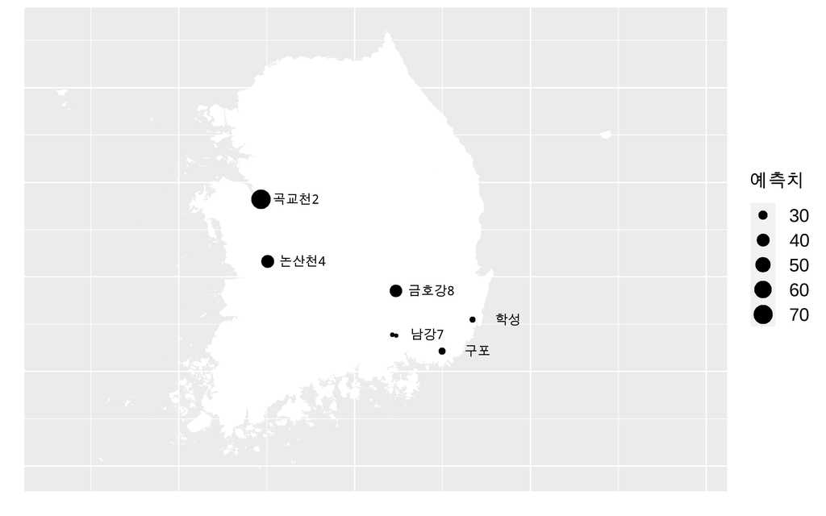

**그림 2-1.녹조 위험 예고 지역**

## 3. 질문기반DB

3.질문기반DB의 내용은 KEI와 서울대학교 행정대학원이 공동으로 개발한 질문중심 DB에 기재된 내용에서 발췌하였다. 원자료는 이하에 기재한 웹사이트로부터 확인할 수 있다.

1. A.대기오염: https://147.47.206.193/SASVisualAnalytics/?reportUri=%2Freports%2Freports%2Ffec6424f-fa2c-4078-8ba5-31e491af1137&sectionIndex=0&sso_guest=true&sas-welcome=false
2. B.기후변화: https://147.47.206.193/SASVisualAnalytics/?reportUri=%2Freports%2Freports%2F23681dc6-2802-4b43-bc8e-636d1154733a&sectionIndex=0&sso_guest=true&sas-welcome=false
3. C. 탄소중립
- 한국: https://lookerstudio.google.com/reporting/3d1b7550-d95b-4cef-aa6b-13f66ca6a5e4
- 국제: https://lookerstudio.google.com/reporting/5049004e-23dc-4da8-a7dc-040c95ce30a3

#### A. 대기오염

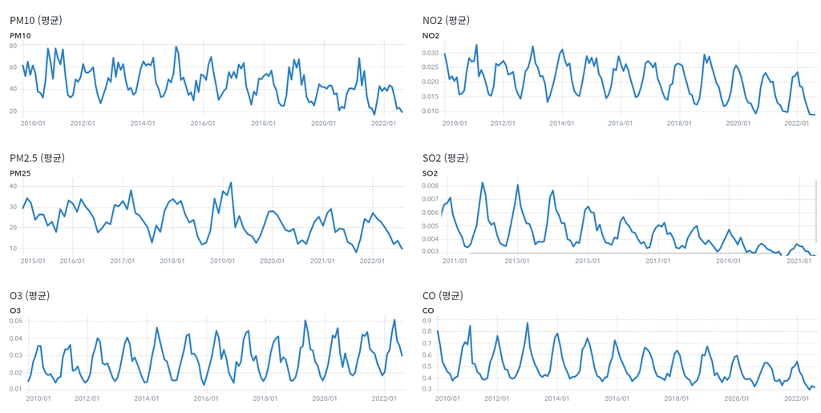

**그림 3-1 대기오염도 전국평균 추이**

#### B.기후변화

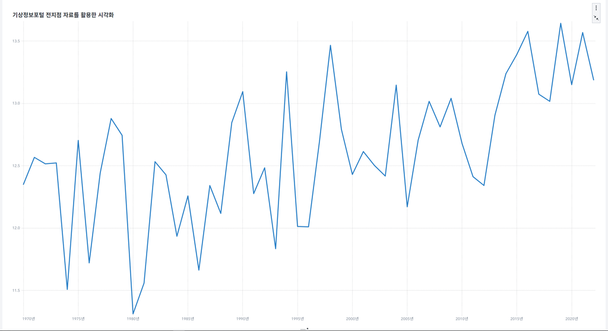

**그림 3-2 전국 평균기온 추이**

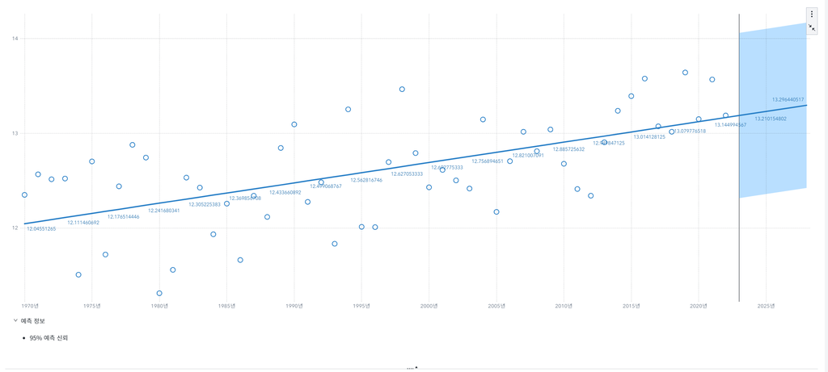

**그림 3-3 전국 평균기온 전망**

#### C.탄소중립

그림 3-4의 왼쪽 그림은 2010년-2019년간 한국의 온실가스 배출량, 오른쪽 그림은 같은 기간 한국의 온실가스 배출량 증가율을 보여준다. 2010년 이후에도 꾸준한 증가 추세를 유지하던 총배출량이 2019년에는 전년 대비 감소하였음을 알 수 있다.

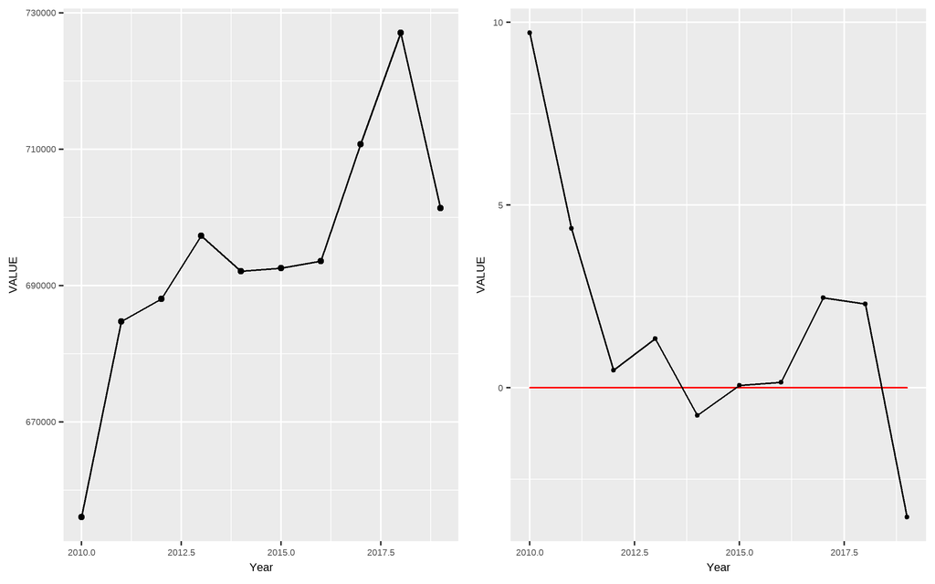

**그림 3-4 한국 온실가스 배출량 추이(2010-2019)**

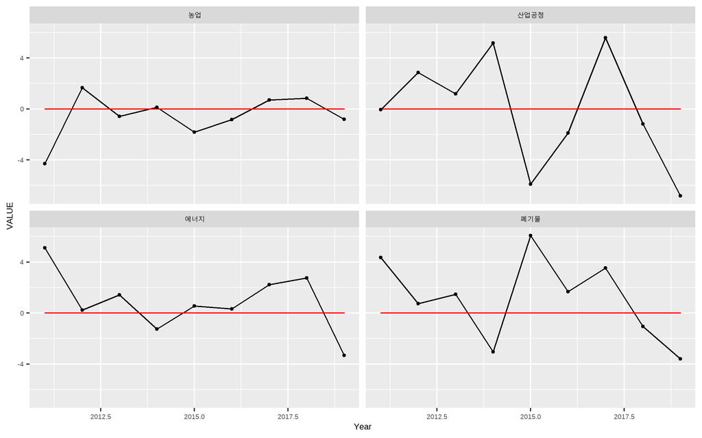

**그림 3-5 한국 부문별 온실가스 배출량 증감률 추이 (2010-2019)**

그림 3-5에서 보여주는 성과에도 불구하고 한국은 1990년-2018년간 세계적으로 가장 빠르게 온실가스 배출량이 증가한 국가이기도 하다. 그림 3-6은 1990년 대비 2018년 국가 별 온실가스 배출량 증감율(%)을 비교하고 있다. 비교 대상 국가 중 한국은 중국에 이어서 두번째로 크게 증가하였음을 알 수 있다.

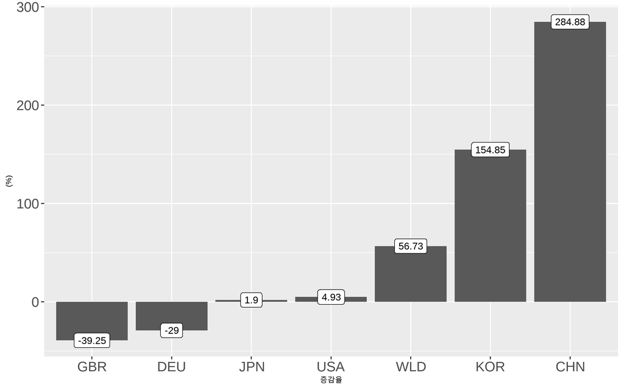